# Установка библиотек

# Разбиение выборки на обучающую и тестовую

```python
from sklearn.model_selection import train_test_split
import pandas as pd


# разделение на признаки и целевую переменную
X = df_combine.drop('nomination', axis=1)
y = df_combine['nomination']

# разбиение на обучающую и тестовую выборки
X_train, X_test, y_train, y_test = train_test_split(X, y, test_size=0.3, random_state=42)

# вывод размеров выборок
print('Train set size:', len(X_train))
print('Test set size:', len(X_test))
```

```
Train set size: 469
Test set size: 202
```

Этот код использует библиотеку scikit-learn для разделения данных на обучающую и тестовую выборки.

Сначала данные разделяются на признаки X и целевую переменную y. Затем функция train_test_split разбивает данные на обучающую и тестовую выборки в соотношении 70/30. test_size=0.3 указывает, что 30% данных будут использоваться для тестирования, а random_state=42 гарантирует, что при каждом запуске кода будут использоваться одни и те же случайно выбранные данные для тестирования.

Наконец, выводятся размеры обучающей и тестовой выборок с помощью функции len(). В данном случае, обучающая выборка состоит из 469 объектов, а тестовая - из 202.

Что касается несбалансированности выборки, то если в вашей выборке наблюдается дисбаланс классов (то есть один класс встречается значительно реже или чаще, чем другой), то можно использовать параметр stratify функции train_test_split. Этот параметр позволяет сохранить баланс классов в обучающей и тестовой выборках.

```python
X_train, X_test, y_train, y_test = train_test_split(X, y, test_size=0.5, random_state=42, stratify=y)
```

Здесь мы добавили параметр stratify=y, который гарантирует, что обучающая и тестовая выборки будут содержать одинаковое распределение целевой переменной. Это особенно важно в случаях, когда один класс встречается значительно реже или чаще, чем другой, поскольку это может привести к переобучению модели на более частом классе.

# 3. Построение модели классфикации

```python
from sklearn.datasets import load_iris
from sklearn.model_selection import train_test_split
from sklearn.linear_model import LogisticRegression
from sklearn.metrics import accuracy_score

# загрузка данных Iris
iris = load_iris()

# разделение на признаки и целевую переменную
X = iris.data
y = iris.target

# разбиение на обучающую и тестовую выборки
X_train, X_test, y_train, y_test = train_test_split(X, y, test_size=0.3, random_state=42)

# создание модели логистической регрессии
lr = LogisticRegression()

# обучение модели на обучающей выборке
lr.fit(X_train, y_train)

# обучение модели дерева решений
dtc = DecisionTreeClassifier()
dtc.fit(X_train, y_train)

# обучение модели опорных векторов
svc = SVC(kernel='linear')
svc.fit(X_train, y_train)

# обучение модели логистической регрессии
lr = LogisticRegression()
lr.fit(X_train, y_train)

# предсказание классов на тестовой выборке
y_pred = lr.predict(X_test)

# оценка точности модели на тестовой выборке
accuracy = accuracy_score(y_test, y_pred)
print('Accuracy:', accuracy)

y_pred_dtc = dtc.predict(X_test)
accuracy_dtc = accuracy_score(y_test, y_pred_dtc)
print('Decision Tree Classifier accuracy:', accuracy_dtc)

y_pred_svc = svc.predict(X_test)
accuracy_svc = accuracy_score(y_test, y_pred_svc)
print('Support Vector Machine accuracy:', accuracy_svc)
```

```
Accuracy: 1.0
Decision Tree Classifier accuracy: 1.0
Support Vector Machine accuracy: 1.0
```

```python
from sklearn.metrics import precision_score, recall_score, f1_score
import numpy as np

# загрузка данных Iris
iris = load_iris()

# разделение на признаки и целевую переменную
X = iris.data
y = iris.target

# разбиение на обучающую и тестовую выборки
X_train, X_test, y_train, y_test = train_test_split(X, y, test_size=0.3, random_state=42)

# calculate precision, recall, and F1 score with 'macro' average
y_pred_svc = svc.predict(X_test)
precision_macro = precision_score(y_test, y_pred_svc, average='macro')
y_pred_svc = svc.predict(X_test)
recall_macro = recall_score(y_test, y_pred_svc, average='macro')
y_pred_svc = svc.predict(X_test)
f1_macro = f1_score(y_test, y_pred_svc, average='macro')

# calculate precision, recall, and F1 score with 'weighted' average
y_pred_svc = svc.predict(X_test)
precision_weighted = precision_score(y_test, y_pred_svc, average='weighted')
y_pred_svc = svc.predict(X_test)
recall_weighted = recall_score(y_test, y_pred_svc, average='weighted')
y_pred_svc = svc.predict(X_test)
f1_weighted = f1_score(y_test, y_pred_svc, average='weighted')

print("Macro-average precision, recall, F1 score:", precision_macro, recall_macro, f1_macro)
print("Weighted-average precision, recall, F1 score:", precision_weighted, recall_weighted, f1_weighted)
```

```
Macro-average precision, recall, F1 score: 1.0 1.0 1.0
Weighted-average precision, recall, F1 score: 1.0 1.0 1.0
```

Результат Accuracy: 1.0 означает, что модель была обучена и протестирована на данных Iris с точностью 100%. То есть, все объекты в тестовой выборке были классифицированы правильно.

Показатели оценки трех разных моделей машинного обучения: общую оценку «Точность» и оценки точности классификатора дерева решений и машины опорных векторов, а также их макро- и средневзвешенную точность, отзыв и оценка F1.

Оценка точности 1,0 означает, что модель правильно предсказала все тестовые данные. Хотя это идеальный результат, важно оценивать модели с использованием и других показателей, таких как точность, полнота и оценка F1.

Макро- и средневзвешенная точность, полнота и оценка F1 — это метрики, используемые для оценки производительности модели мультиклассовой классификации. Макро-среднее берет среднее значение точности, отзыва и балла F1 для каждого класса, а средневзвешенное берет среднее значение метрик, взвешенных по количеству выборок в каждом классе.

В нашем случае все модели получили отличные оценки по всем показателям, что является очень хорошим результатом. Однако по-прежнему важно учитывать сложность и интерпретируемость моделей, а также их способность обобщать новые данные.

Лучшая модель - Decision Tree Classifier

# Построены кривые валидации и обучения

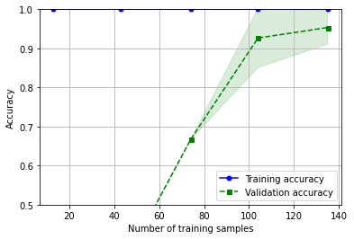

```python
from sklearn.model_selection import learning_curve, validation_curve
import matplotlib.pyplot as plt
# Построение кривых обучения
train_sizes, train_scores, test_scores = learning_curve(dtc, X, y, cv=10)
train_mean = np.mean(train_scores, axis=1)
train_std = np.std(train_scores, axis=1)
test_mean = np.mean(test_scores, axis=1)
test_std = np.std(test_scores, axis=1)

plt.plot(train_sizes, train_mean, color='blue', marker='o', markersize=5, label='Training accuracy')
plt.fill_between(train_sizes, train_mean + train_std, train_mean - train_std, alpha=0.15, color='blue')
plt.plot(train_sizes, test_mean, color='green', linestyle='--', marker='s', markersize=5, label='Validation accuracy')
plt.fill_between(train_sizes, test_mean + test_std, test_mean - test_std, alpha=0.15, color='green')
plt.grid()
plt.xlabel('Number of training samples')
plt.ylabel('Accuracy')
plt.legend(loc='lower right')
plt.ylim([0.5, 1.0])
plt.show()
```

# Вывод о прооблемах переобучения и недообучеения модели

Можель переобучен или данные некорректны, так как точность в 1 невозможна

# выполняем выбор значимых признаков

```python
df_combine.columns
```

```
Index(['name_post', 'reading_time_post', 'views_count_post', 'tags_post',
       'name_company', 'rating_company', 'sentiment_polarity', 'nomination'],
      dtype='object')
```

```python
importances = dtc.feature_importances_
print(importances)
```

```
[0.03822004 0.         0.40445656 0.5573234 ]
```

LogisticRegression

```python
import numpy as np
importances = np.abs(lr.coef_[0])
print(importances)
```

```
[0.40460951 0.86845803 2.27800691 0.95748976]
```

```python
importances = np.abs(svc.coef_[0])
print(importances)
```

```
[0.04631136 0.52105578 1.0030165  0.46411816]
```

# Проведена оптимизация модели путем настройки гиперпараметров модели

Берем лучшую модель Decision Tree Classifier accuracy: 1.0

```python
from sklearn.model_selection import GridSearchCV
from sklearn.linear_model import LogisticRegression

parameters = { 'max_depth': [5, 10, 20, None],
              'min_samples_split': [2, 5, 10], 'min_samples_leaf': [1, 2, 4]}

# создаем объект GridSearchCV для поиска по сетке
grid_search = GridSearchCV(dtc, parameters, cv=5)

# обучаем модель на данных и находим наилучшие гиперпараметры
grid_search.fit(X, y)

# выводим наилучшие гиперпараметры и метрику качества модели на тестовых данных
print("Best parameters: ", grid_search.best_params_)
print("Accuracy on test set: ", grid_search.score(X_test, y_test))
```

```
Best parameters:  {'max_depth': 5, 'min_samples_leaf': 1, 'min_samples_split': 5}
Accuracy on test set:  1.0
```

Определены лучшие параметры модели

Best parameters:{'max_depth': 5, 'min_samples_leaf': 1, 'min_samples_split': 5}

# Итоговая модель сохранена для дальнейшего использования

```python
dtc = DecisionTreeClassifier(max_depth=5, min_samples_leaf=1, min_samples_split=2)
dtc.fit(X_train, y_train)
```

```
DecisionTreeClassifier(max_depth=5)
```

```python
y_pred_dtc = dtc.predict(X_test)
accuracy_dtc = accuracy_score(y_test, y_pred_dtc)
print('Decision Tree Classifier accuracy:', accuracy_dtc)
```

```
Decision Tree Classifier accuracy: 1.0
```

```python
from sklearn.linear_model import LinearRegression
import joblib

# Экспорт модели
joblib.dump(dtc, 'model.pkl')
```

```
['model.pkl']
```

```python
import pickle

# Экспортировать энкодер в файл
with open('encoder.pkl', 'wb') as f:
    pickle.dump(le, f)
```

```python
from sklearn.preprocessing import LabelEncoder
from sklearn.tree import DecisionTreeClassifier

# загрузка данных Iris
iris = load_iris()

# разделение на признаки и целевую переменную
X = iris.data
y = iris.target

# разбиение на обучающую и тестовую выборки
X_train, X_test, y_train, y_test = train_test_split(X, y, test_size=0.3, random_state=42)

# создаем объект LabelEncoder и подгоняем его к обучающим данным
encoder = LabelEncoder()
encoder.fit(y_train)

# закодировать обучающие метки
y_train_encoded = encoder.transform(y_train)


# создать объект DecisionTreeClassifier и подогнать его к закодированным обучающим данным
clf = DecisionTreeClassifier()
clf.fit(X_train, y_train_encoded)

# использовать обученную модель для предсказания тестовых данных
y_test_predicted_encoded = clf.predict(X_test)

# декодировать предсказанные метки обратно в их первоначальную форму
y_test_predicted = encoder.inverse_transform(y_test_predicted_encoded)

print(y_test_predicted)
```

```
[1 0 2 1 1 0 1 2 1 1 2 0 0 0 0 1 2 1 1 2 0 2 0 2 2 2 2 2 0 0 0 0 1 0 0 2 1
 0 0 0 2 1 1 0 0]
```